# Trabajo 2

### 1.6.3 c comparacion por AIC,BIC

**Mostrar/ocultar código**

```r
# AIC() y BIC() de R: todos los candidatos con ML exacta, mismo d y misma especificación
tabla_crit_st1 <- do.call(rbind, lapply(seq_along(ajustes_st1), function(i) {
  mod <- ajustes_st1[[i]]$modelo
  data.frame(
    modelo = paste0("ARIMA(", paste(candidatos_st1[[i]], collapse = ","), ")"),
    sigma2 = ajustes_st1[[i]]$sigma2,
    logLik = as.numeric(logLik(mod)),
    AIC    = AIC(mod),
    BIC    = BIC(mod)
  )
}))
tabla_crit_st1
```

| modelo | sigma2 | logLik | AIC | BIC |
| --- | --- | --- | --- | --- |
| ARIMA(1,2,0) | 0.10046870 | -30.65781 | 65.31563 | 70.77040 |
| ARIMA(0,2,1) | 0.09640223 | -28.33624 | 60.67249 | 66.12726 |
| ARIMA(1,2,1) | 0.09268811 | -26.16767 | 58.33533 | 66.51750 |

### 1.6.4 d contraste

**Mostrar/ocultar código**

```r
# Contraste declarado: se aplica después de la identificación propia
auto_st1 <- forecast::auto.arima(gZ_st1,
                                 test = "kpss",          # prueba para decidir d
                                 ic = "bic",             # mismo criterio que SBC
                                 seasonal = FALSE,
                                 stepwise = FALSE,       # búsqueda exhaustiva
                                 approximation = FALSE)  # ML exacta
auto_st1
```

```
Series: gZ_st1
ARIMA(2,2,0)

Coefficients:
         ar1      ar2
      0.6929  -0.3635
s.e.  0.0873   0.0881

sigma^2 = 0.09439:  log likelihood = -22.78
AIC=51.55   AICc=51.77   BIC=59.74
```

**Mostrar/ocultar código**

```r
forecast::arimaorder(auto_st1)
```

```
p d q
2 2 0
```

## 1.7 7 Seleccion del modelo

### 1.7.1 a raices

**Mostrar/ocultar código**

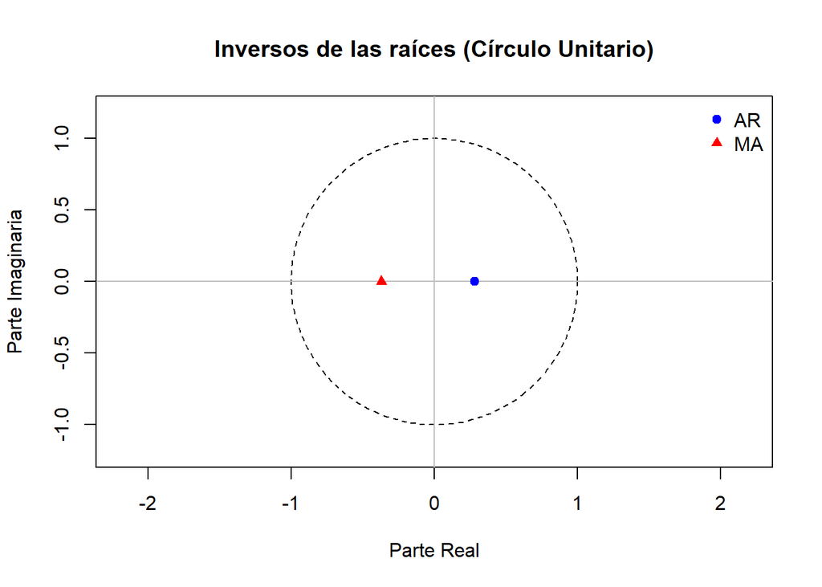

```r
raices_st1 <- raices_modelo(modelo_st1)     # dibuja las raíces inversas
```

**Mostrar/ocultar código**

```r
raices_st1[c("modulos_ar", "modulos_ma", "estacionario", "invertible")]
```

```
$modulos_ar
[1] 3.546826

$modulos_ma
[1] 2.708507

$estacionario
[1] TRUE

$invertible
[1] TRUE
```

**Mostrar/ocultar código**

```r
# Posibles factores comunes: distancias entre raíces AR y MA
if (length(raices_st1$raices_ar) > 0 && length(raices_st1$raices_ma) > 0) {
  round(abs(outer(raices_st1$raices_ar, raices_st1$raices_ma, "-")), 3)
}
```

```
      [,1]
[1,] 6.255
```

### 1.7.2 b prueba t

**Mostrar/ocultar código**

```r
tabla_t_st1 <- tabla_coef(modelo_st1)
tabla_t_st1$t_valor <- tabla_t_st1$estimacion / tabla_t_st1$error_estandar
tabla_t_st1$p_valor <- 2 * pnorm(-abs(tabla_t_st1$t_valor))
tabla_t_st1
```

| parametro | estimacion | error_estandar | li | ls | t_valor | p_valor |
| --- | --- | --- | --- | --- | --- | --- |
| ar1 | 0.2819422 | 0.1248471 | 0.03724635 | 0.5266381 | 2.258300 | 0.0239269839 |
| ma1 | 0.3692071 | 0.1049918 | 0.16342699 | 0.5749872 | 3.516534 | 0.0004372214 |

**Mostrar/ocultar código**

```r
# Matriz de correlaciones de los estimadores
round(cov2cor(modelo_st1$matriz_covarianzas), 3)
```

```
       ar1    ma1
ar1  1.000 -0.696
ma1 -0.696  1.000
```

### 1.7.3 c Residuos ACF,PACF y ljun-box

**Mostrar/ocultar código**

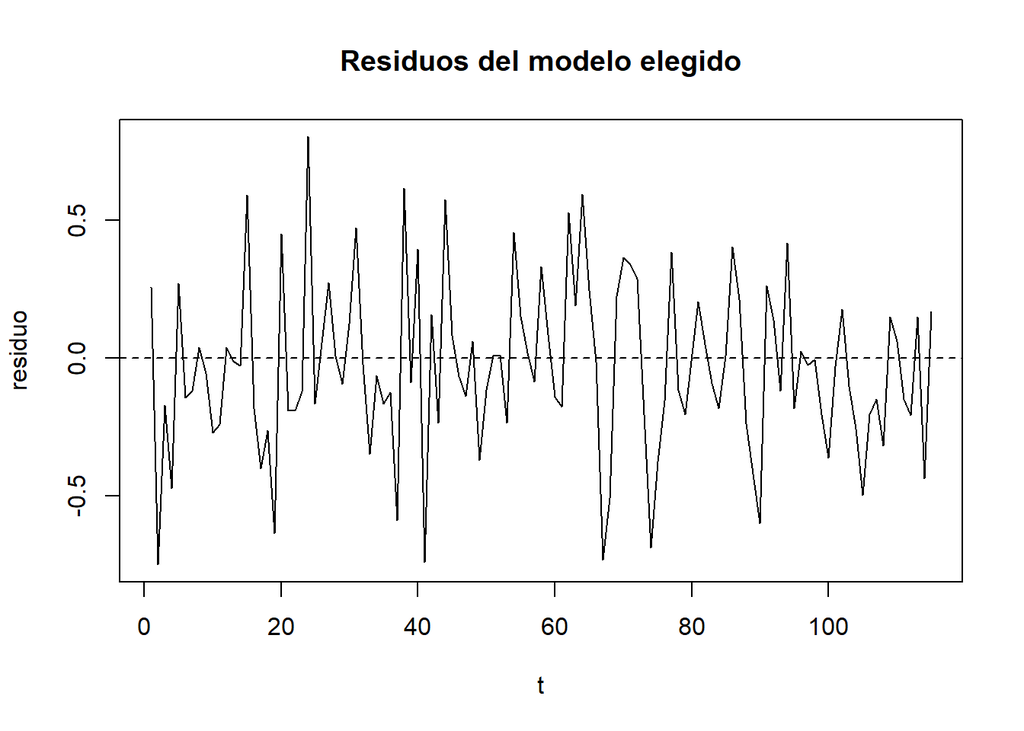

```r
res_st1 <- modelo_st1$residuos

plot(res_st1, type = "l", main = "Residuos del modelo elegido",
     xlab = "t", ylab = "residuo")
abline(h = 0, lty = 2)
```

**Mostrar/ocultar código**

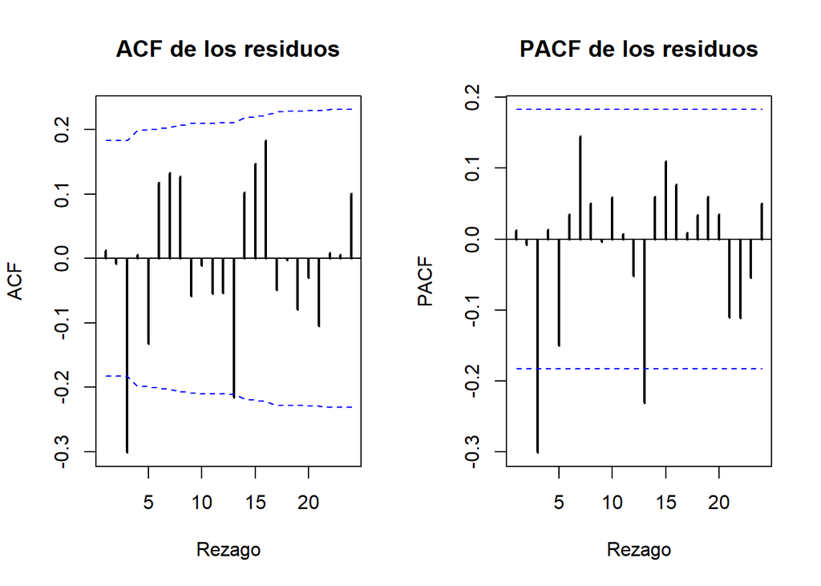

```r
id_res_st1 <- acf_pacf_muestral(res_st1, m = 24, titulo = "de los residuos")
```

**Mostrar/ocultar código**

```r
ljung_st1 <- ljung_box(modelo_st1, rezagos = c(6, 12, 18, 24))
ljung_st1
```

| rezago | gl | estadistico_Q | p_valor |
| --- | --- | --- | --- |
| 6 | 4 | 14.79565 | 0.005144376 |
| 12 | 10 | 20.21795 | 0.027257373 |
| 18 | 16 | 35.57084 | 0.003317572 |
| 24 | 22 | 39.68152 | 0.011775682 |

### 1.7.4 d normalidad de residuous

**Mostrar/ocultar código**

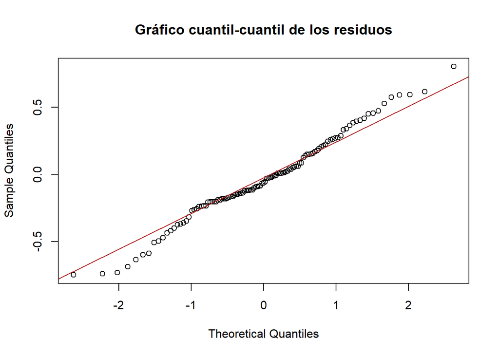

```r
qqnorm(res_st1, main = "Gráfico cuantil-cuantil de los residuos")
qqline(res_st1, col = "firebrick")
```

**Mostrar/ocultar código**

```r
jb_st1 <- jarque_bera(res_st1)
jb_st1
```

```
$asimetria
[1] 0.07511708

$curtosis
[1] 3.074302

$JB
[1] 0.1346032

$gl
[1] 2

$p_valor
[1] 0.9349132
```

**Mostrar/ocultar código**

```r
# Verificación con tseries (opcional)
tseries::jarque.bera.test(res_st1)
```

```
    Jarque Bera Test

data:  res_st1
X-squared = 0.1346, df = 2, p-value = 0.9349
```

### 1.7.5 e sobreajuste

**Mostrar/ocultar código**

```r
sobre_st1 <- sobreajuste(Serie_1, modelo_st1, lambda = lambda_st1,
                         constante = args_elegido$constante,
                         tendencia = args_elegido$tendencia)
sobre_st1$parametros_extra
```

|  | estimacion | error_estandar | t_valor | p_valor |
| --- | --- | --- | --- | --- |
| Sobreajuste_AR (2,2,1) -> ar2 | -0.4532976 | 0.1137354 | -3.985546 | 6.732505e-05 |
| Sobreajuste_MA (1,2,2) -> ma2 | 0.5592347 | 0.1080316 | 5.176583 | 2.259865e-07 |

**Mostrar/ocultar código**

```r
sobre_st1$criterios
```

|  | logLik | AIC | AICc | BIC |
| --- | --- | --- | --- | --- |
| Base | -26.16767 | 58.33533 | 58.55552 | 66.51750 |
| Sobreajuste_AR | -22.35792 | 52.71583 | 53.08620 | 63.62538 |
| Sobreajuste_MA | -21.89813 | 51.79625 | 52.16662 | 62.70580 |

### 1.7.6 f ciclo

**Mostrar/ocultar código**

```r
# Chequeos de todos los candidatos: Ljung-Box por candidato
lapply(ajustes_st1, ljung_box, rezagos = c(6, 12, 18, 24))
```

```
[[1]]
  rezago gl estadistico_Q      p_valor
1      6  5      22.06664 5.085438e-04
2     12 11      30.13237 1.510484e-03
3     18 17      48.52669 7.131352e-05
4     24 23      52.52542 4.248890e-04

[[2]]
  rezago gl estadistico_Q      p_valor
1      6  5      18.92644 0.0019837264
2     12 11      25.89870 0.0067189181
3     18 17      42.07784 0.0006535425
4     24 23      47.33375 0.0020339866

[[3]]
  rezago gl estadistico_Q     p_valor
1      6  4      14.79565 0.005144376
2     12 10      20.21795 0.027257373
3     18 16      35.57084 0.003317572
4     24 22      39.68152 0.011775682
```

# 2 Serie 2

**Mostrar/ocultar código**

```r
# Dias de espera promedio para cita

Serie_2 <- leer_serie("../datos/ST4HTU-serie-2.csv", "Red de Salud de Valdeflores", "Dias de espera promedio")
```

**Mostrar/ocultar código**

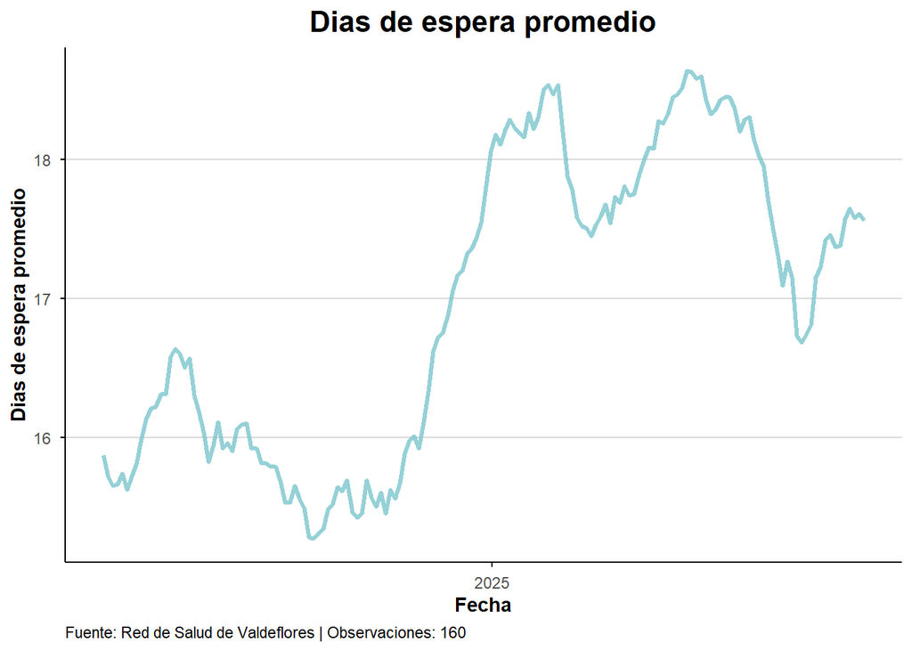

```r
graficar_serie(Serie_2, "Dias de espera promedio", mostrar_puntos = FALSE)
```

**Mostrar/ocultar código**

```
$acf
 [1] 0.9884179 0.9717465 0.9518150 0.9292916 0.9055737 0.8801239 0.8528984
 [8] 0.8258365 0.7999521 0.7737816 0.7495265 0.7269841 0.7039407 0.6811424
[15] 0.6592367 0.6368885 0.6145585 0.5944530 0.5737204 0.5518531 0.5289857
[22] 0.5042368 0.4787973 0.4555972

$panel
```

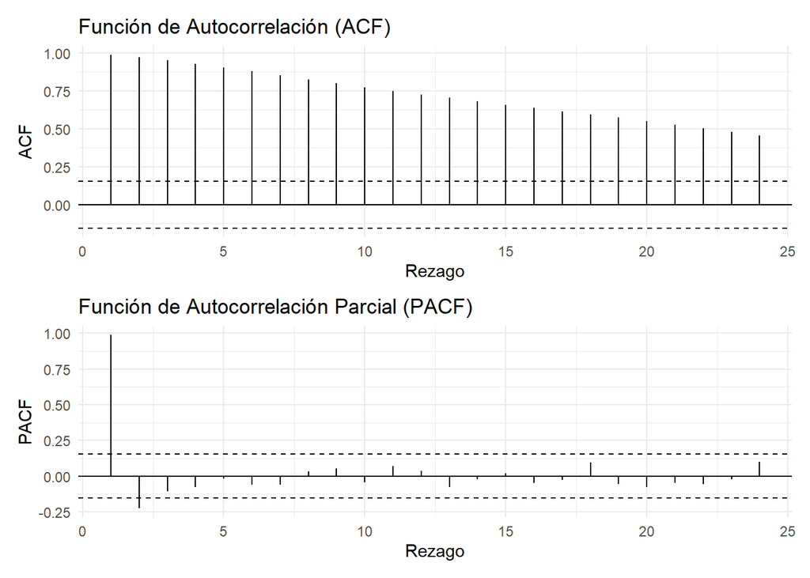

```
$diferencia_maxima
[1] 0.5161493
```

```r
correlograma(Serie_2)
```

# 3 Serie 3

**Mostrar/ocultar código**

```r
# Valor de facturas Original

Serie_3 <- leer_serie("../datos/ST4HTU-serie-3.csv", "Red de Salud de Valdeflores", "millones de pesos")
```

**Mostrar/ocultar código**

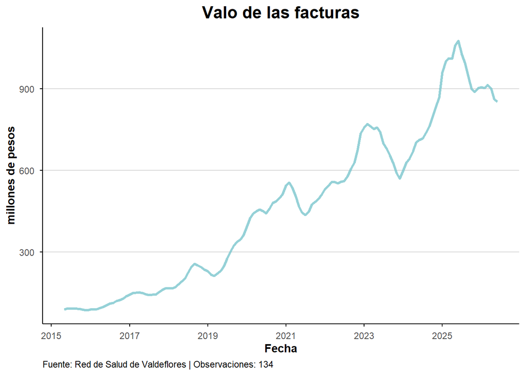

```r
graficar_serie(Serie_3, "Valo de las facturas", mostrar_puntos = FALSE)
```

**Mostrar/ocultar código**

```
$acf
 [1] 0.9843254 0.9646811 0.9413622 0.9159137 0.8898804 0.8635359 0.8376534
 [8] 0.8125169 0.7874810 0.7612306 0.7335243 0.7051143 0.6751874 0.6461621
[15] 0.6195213 0.5936720 0.5691678 0.5469173 0.5291479 0.5137437 0.4999616
[22] 0.4874654 0.4752373 0.4626519

$panel
```

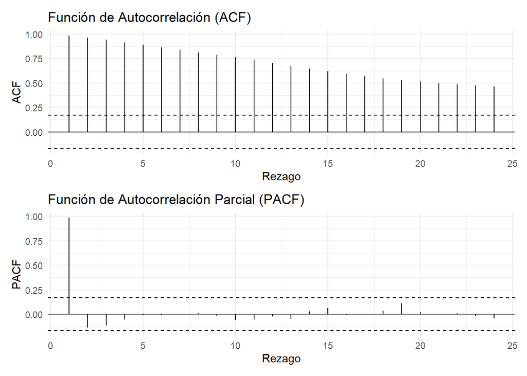

```
$diferencia_maxima
[1] 0.5020293
```

```r
correlograma(Serie_3)
```